# Cwiczenia_3_Zadanie_4

Przygotowali Michał Surówka oraz Wojciech Żelasko

10/16/2023

## Zadanie 4

Zaczynamy od załadowania pakietów dplyr, zoo oraz ggplot2 które zostaną wykorzystane podczas preprocessingu oraz wizualizacji danych.

```r
library(dplyr)
library(zoo)
```

```r
library(ggplot2)
```

Importujemy dane cars.txt i zapisujemy pod zmienna cars oraz zmieniamy typ danych kolumny ‘cubicinches’ na numeric.

```r
cars <- read.table("cars.txt",header = TRUE, sep = ",")
cars$cubicinches <- as.numeric(cars$cubicinches)
```

Następnie sprawdzamy poprawność wczytanych danych:

```r
str(cars)
```

```
## 'data.frame':    261 obs. of  8 variables:
##  $ mpg        : num  14 31.9 17 15 30.5 0 13 14 25.4 37.7 ...
##  $ cylinders  : int  8 4 8 8 4 8 8 8 5 4 ...
##  $ cubicinches: num  350 89 302 400 98 350 351 440 183 89 ...
##  $ hp         : int  165 71 140 150 63 1125 158 215 77 62 ...
##  $ weightlbs  : int  4209 1925 3449 3761 2051 3900 4363 4312 3530 2050 ...
##  $ time.to.60 : int  12 14 11 10 17 17 13 9 20 17 ...
##  $ year       : int  1972 1980 1971 1971 1978 1980 1974 1971 1980 1982 ...
##  $ brand      : chr  " US." " Europe." " US." " US." ...
```

```r
summary(cars)
```

```
##       mpg            cylinders       cubicinches          hp
##  Min.   :   0.00   Min.   : 0.000   Min.   : 68.0   Min.   :-125.0
##  1st Qu.:  16.70   1st Qu.: 4.000   1st Qu.:103.0   1st Qu.:  75.0
##  Median :  22.00   Median : 6.000   Median :156.0   Median :  95.0
##  Mean   :  31.85   Mean   : 5.719   Mean   :201.4   Mean   : 116.2
##  3rd Qu.:  28.90   3rd Qu.: 8.000   3rd Qu.:303.0   3rd Qu.: 139.0
##  Max.   :1236.00   Max.   :42.000   Max.   :455.0   Max.   :1175.0
##  NA's   :2         NA's   :1        NA's   :2
##    weightlbs       time.to.60         year         brand
##  Min.   : 1613   Min.   : 8.00   Min.   :1971   Length:261
##  1st Qu.: 2246   1st Qu.:14.00   1st Qu.:1974   Class :character
##  Median : 2830   Median :16.00   Median :1977   Mode  :character
##  Mean   : 3184   Mean   :15.55   Mean   :1977
##  3rd Qu.: 3654   3rd Qu.:17.00   3rd Qu.:1980
##  Max.   :42135   Max.   :25.00   Max.   :1983
##  NA's   :2                       NA's   :1
```

Po wstępnej ocenie problemu wyświetlamy histogramy poszczególnych zmiennych w celu określenia które zmienne są bardziej podatne na wartości odstające.

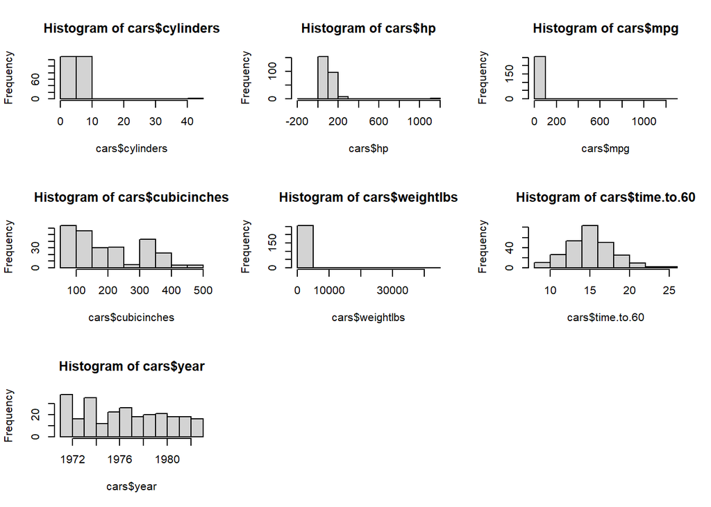

```r
par(mfrow=c(3,3))
hist(cars$cylinders)
hist(cars$hp)
hist(cars$mpg)
hist(cars$cubicinches)
hist(cars$weightlbs)
hist(cars$time.to.60)
hist(cars$year)
```

Następnie z wykorzystaniem funkcji mutate oraz na podstawie własnej wiedzy i informacji znalezionych w internecie przeprowadzamy wstępny preprocessing wraz z usunieciem wartości odstających dla kolumn mpg, cylinders, cubicinches oraz hp.

```r
cars2 = cars %>%
  mutate(mpg2 = ifelse(cars$mpg < 0 | cars$mpg > 70, NA, cars$mpg),
         cylinders2 = ifelse(cars$cylinders > 8 | cars$cylinders < 2 , NA, cars$cylinders),
         cubicinches2 = ifelse(cars$cubicinches > 400, NA, cars$cubicinches),
         hp2 = ifelse(cars$hp > 300 | cars$hp < 0, NA, cars$hp))
cars3<-cars2
cars2<-distinct(cars2)
```

Jedną z metod które wykorzystujemy to powstałe wartości NA zastępujemy z wykorzystaniem funkcji na.approx().

```r
cars2$mpg2 = na.approx(cars2$mpg2, rule=2)
cars2$cylinders2 = na.approx(cars2$cylinders2, rule=2)
cars2$cubicinches2 = na.approx(cars2$cubicinches2, rule = 2)
cars2$hp2 = na.approx(cars2$hp2, rule = 2)
```

Aby porównać nasze wyniki wykonujemy po raz kolejny histogramy dla powyższych zmiennych.

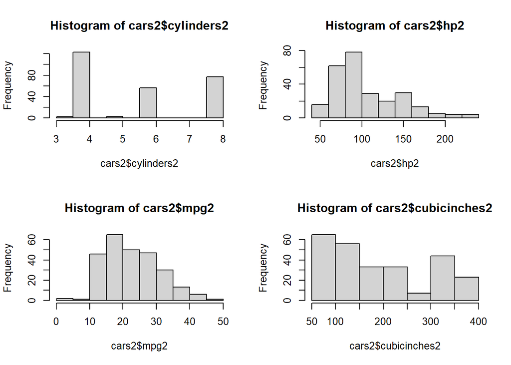

```r
par(mfrow=c(2,2))
hist(cars2$cylinders2)
hist(cars2$hp2)
hist(cars2$mpg2)
hist(cars2$cubicinches2)
```

Powyższe histogramy na pierwszy rzut oka od razu wyglądają znacznie lepiej niż na danych przed preprocessingiem.

```r
cars3 <- cars3 %>%
  group_by(brand) %>%
  mutate(
    hp2=ifelse(is.na(hp2), mean(hp2, na.rm = TRUE),hp),
    mpg2=ifelse(is.na(mpg2), mean(mpg2, na.rm = TRUE), mpg),
    cubicinches2=ifelse(is.na(cubicinches2), mean(cubicinches2, na.rm = TRUE), cubicinches2),
    cylinders2=ifelse(is.na(cylinders2),as.numeric(names(sort(table(cylinders2)))[1]),cylinders)
    ) %>%
  ungroup()
cars3
```

```
## # A tibble: 261 × 12
##      mpg cylinders cubicinches    hp weightlbs time.to.60  year brand       mpg2
##    <dbl>     <int>       <dbl> <int>     <int>      <int> <int> <chr>      <dbl>
##  1  14           8         350   165      4209         12  1972 " US."      14
##  2  31.9         4          89    71      1925         14  1980 " Europe."  31.9
##  3  17           8         302   140      3449         11  1971 " US."      17
##  4  15           8         400   150      3761         10  1971 " US."      15
##  5  30.5         4          98    63      2051         17  1978 " US."      30.5
##  6   0           8         350  1125      3900         17  1980 " US."       0
##  7  13           8         351   158      4363         13  1974 " US."      13
##  8  14           8         440   215      4312          9  1971 " US."      14
##  9  25.4         5         183    77      3530         20  1980 " Europe."  25.4
## 10  37.7         4          89    62      2050         17  1982 " Japan."   37.7
## # ℹ 251 more rows
## # ℹ 3 more variables: cylinders2 <dbl>, cubicinches2 <dbl>, hp2 <dbl>
```

Teraz w celach weryfikacji ponownie analizujemy histogramy oraz ploty.

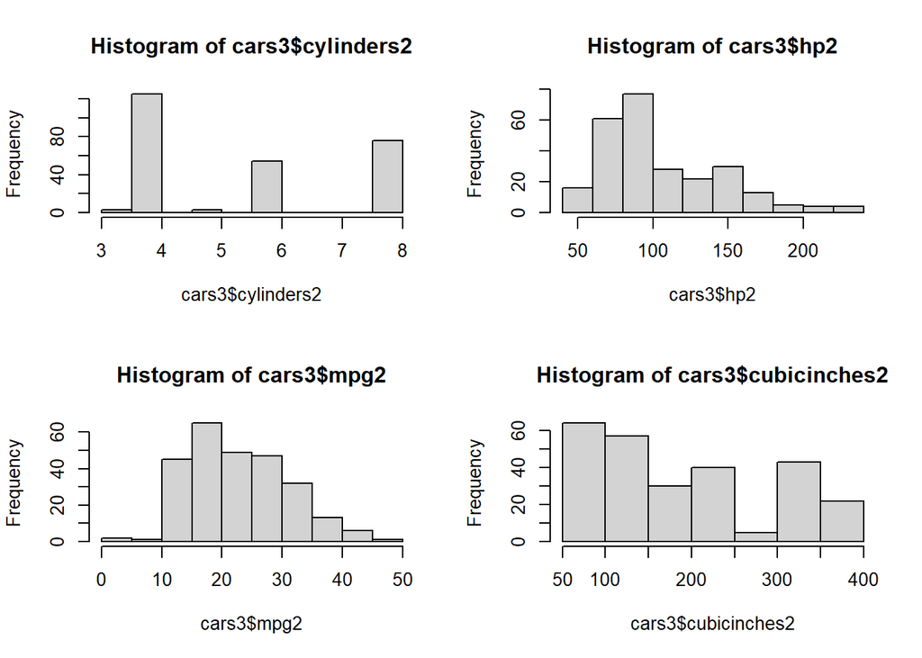

```r
par(mfrow=c(2,2))
hist(cars3$cylinders2)
hist(cars3$hp2)
hist(cars3$mpg2)
hist(cars3$cubicinches2)
```

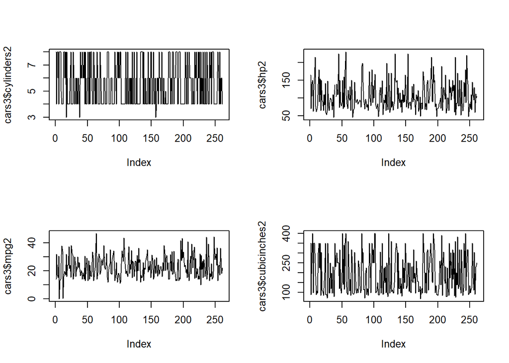

```r
par(mfrow=c(2,2))
plot(cars3$cylinders2, type="l")
plot(cars3$hp2, type="l")
plot(cars3$mpg2, type="l")
plot(cars3$cubicinches2, type="l")
```

W celach testowych wykorzystujemy regułę 3 sigm. Możliwe że ze wzgledu na fakt że mamy do czynienia z większym zbiorem danych, ta metoda będzie bardziej skuteczna. Sprawzimy to na zmiennej mpg.

```r
mean(cars2$mpg2,na.rm=TRUE) + (3*sd(cars2$mpg2,na.rm = TRUE))#46.94349
```

```
## [1] 46.94349
```

```r
mean(cars2$mpg2,na.rm=TRUE) - (3*sd(cars2$mpg2,na.rm = TRUE))#-1.174138
```

```
## [1] -1.174138
```

```r
cars4<-mutate(cars2, mpg2=ifelse(mpg2<46.94 & mpg2>-1.17,mpg2,NA))
```

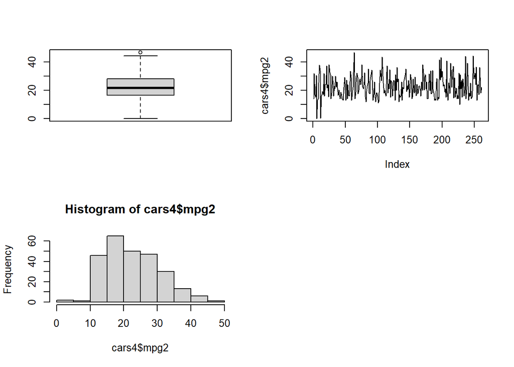

```r
par(mfrow=c(2,2))
boxplot(cars4$mpg2)
plot(cars4$mpg2, type="l")
hist(cars4$mpg2, breaks=8)
```